# NEUROSYSM930

If you are not familiar, a box plot or boxplot is a method for demonstrating graphically the locality, spread and skewness groups of numerical data through their quartiles [text from wiki] In addition to the box on a box plot, there can be lines (which are called whiskers) extending from the box indicating variability outside the upper and lower quartiles, thus, the plot is also called the box-and-whisker plot and the box-and-whisker diagram. Outliers that differ significantly from the rest of the dataset may be plotted as individual points beyond the whiskers on the box-plot. Box plots are non-parametric: they display variation in samples of a statistical population without making any assumptions of the underlying statistical distribution (though Tukey’s boxplot assumes symmetry for the whiskers and normality for their length).

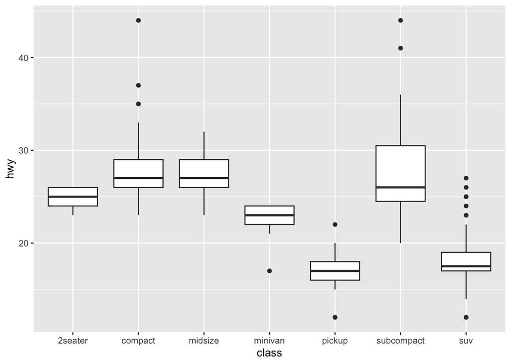

```r
# 2.2.2  make a boxplot
ggplot(mpg) +
  geom_boxplot(aes(x = class, y = hwy))
```

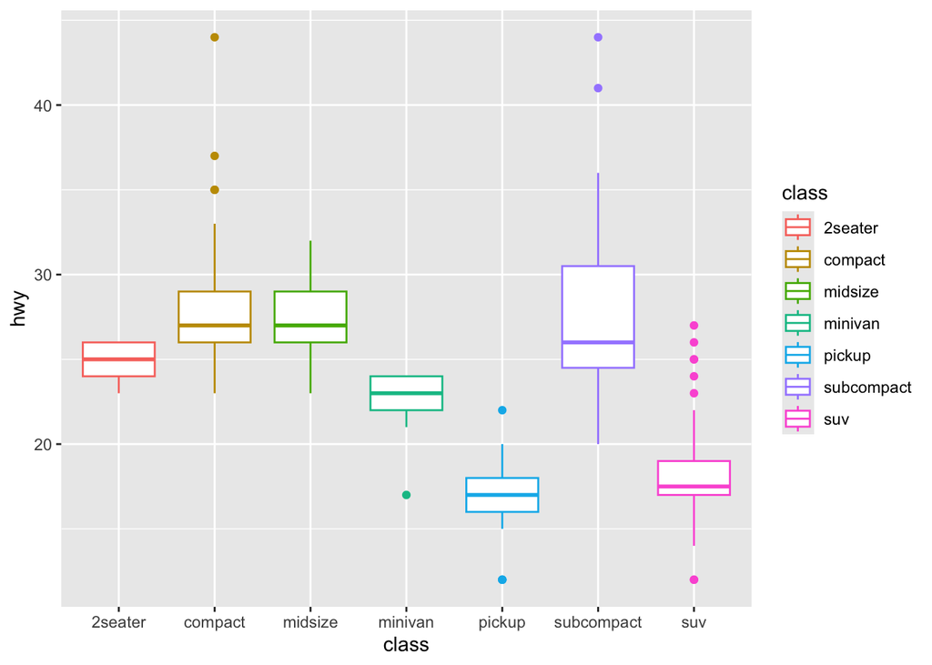

```r
# and play with it
ggplot(mpg) +
  geom_boxplot(aes(x = class, y = hwy,color=class))
```

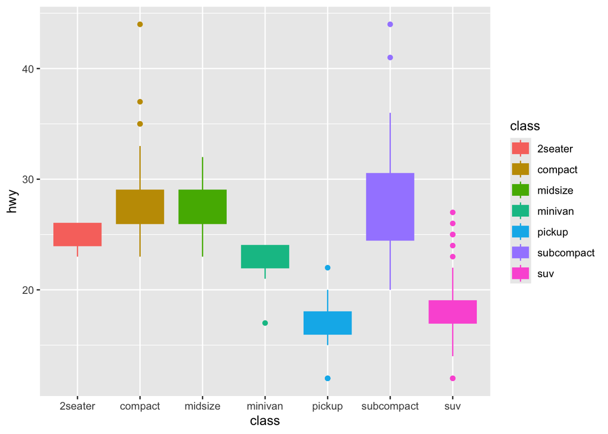

```r
ggplot(mpg) +
  geom_boxplot(aes(x = class, y = hwy,color=class,fill=class))
```

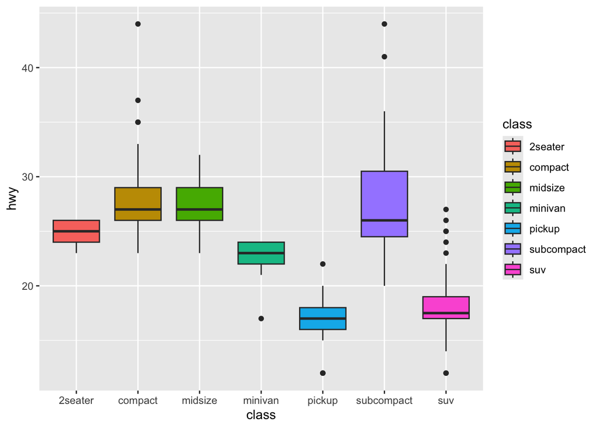

```r
ggplot(mpg) +
  geom_boxplot(aes(x = class, y = hwy,fill=class))
```

The beauty of ggplot is that we can tune so many different parameters based on your needs and your artistic spirit =) But, you dont have to memorise all of these arguments. You can google online, or you can have some templates that serve your needs or your visualisation requirements.

For example:

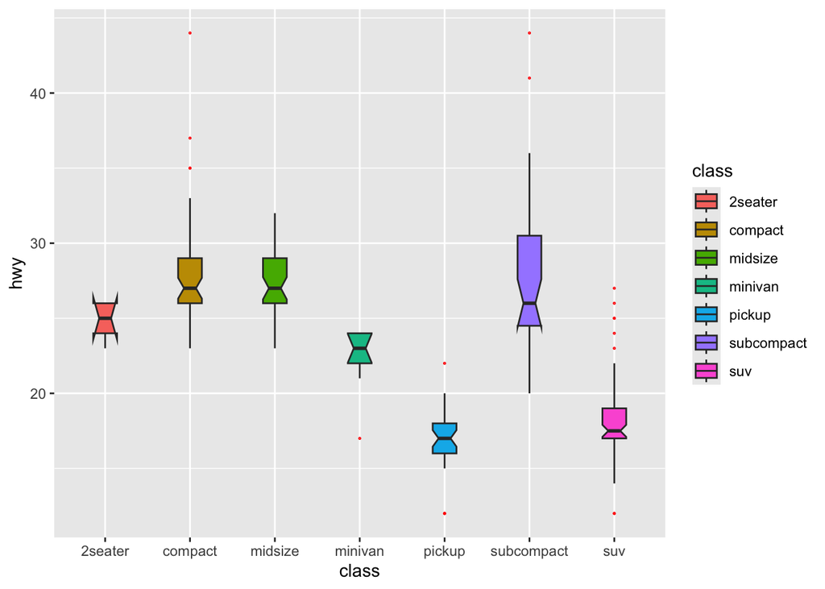

```r
ggplot(mpg) +
  geom_boxplot(aes(x = class, y = hwy,fill=class),
               width=0.28,
               outlier.colour = "red",
               outlier.shape = 1,
               outlier.fill = "red",
               outlier.size = 0.2,notch = TRUE)
```

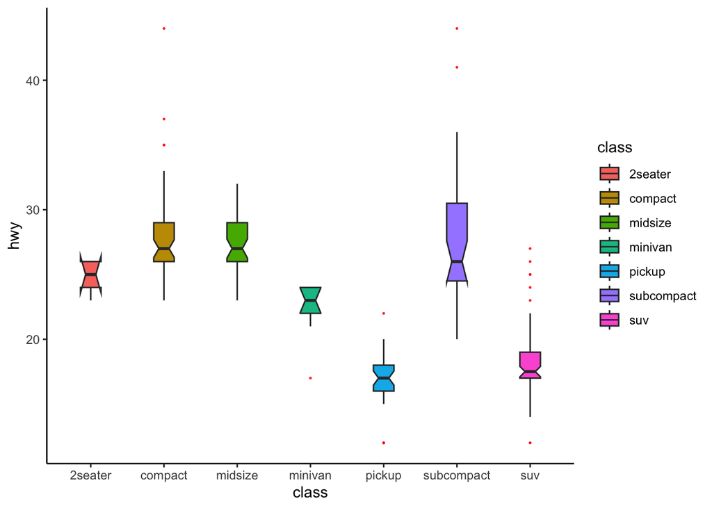

```r
ggplot(mpg) +
  geom_boxplot(aes(x = class, y = hwy,fill=class),
               width=0.28,
               outlier.colour = "red",
               outlier.shape = 1,
               outlier.fill = "red",
               outlier.size = 0.2,notch = TRUE)+
   theme_classic()
```

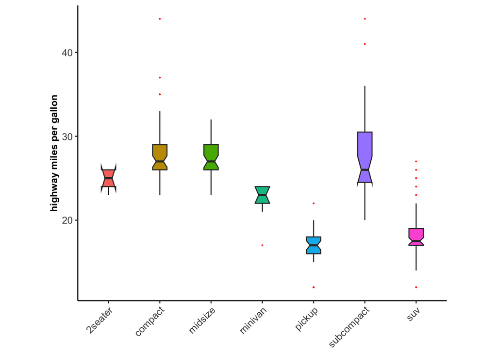

```r
ggplot(mpg) +
  geom_boxplot(aes(x = class, y = hwy,fill=class),
               width=0.28,
               outlier.colour = "red",
               outlier.shape = 1,
               outlier.fill = "red",
               outlier.size = 0.2,notch = TRUE)+
  theme_classic() +
  ylab('highway miles per gallon')+
  theme(axis.text.y = element_text( size = 10 ),
      axis.text.x = element_text(angle = 45, vjust = 1, hjust = 1, size = 10),
      axis.title.x = element_blank(),
      axis.title.y = element_text( size = 10, face='bold' ),
      legend.position = "none",
      aspect.ratio = 0.8)
```

Notice that ggplot offers many pre-defined themes that change a lot the appearance of the layout or the background of the plot. More customised themes are also available online and they can be downloaded and installed as standalone R packages, or they are parts of bigger analysis packages.

But, can we save plots ?? The answer is **YES**

```r
#remember to check your own folder directory
output_file <- file.path(path, "my_first_nice_boxplot.png")
ggsave(output_file)
```

Now lets see another way to save a plot. The following example stores the ggplot into a variable which can be very useful too.

```r
myFigure <- ggplot(mpg) +
  geom_boxplot(aes(x = class, y = hwy,fill=class),
               width=0.28,
               outlier.colour = "red",
               outlier.shape = 1,
               outlier.fill = "red",
               outlier.size = 0.2,notch = TRUE)+
  theme_classic() +
  ylab('highway miles per gallon')+
  theme(axis.text.y = element_text( size = 10 ),
        axis.text.x = element_text(angle = 45, vjust = 1, hjust = 1, size = 14),
        axis.title.x = element_blank(),
        axis.title.y = element_text( size = 10, face='bold' ),
        legend.position = "none",
        aspect.ratio = 0.8)

class(myFigure)
```

```
[1] "gg"     "ggplot"
```

```r
output_file <- file.path(path, "my_first_nice_boxplot2.pdf")
pdf(output_file)
plot(myFigure)
dev.off()
```

Lets make a simple and a more fancy histogram

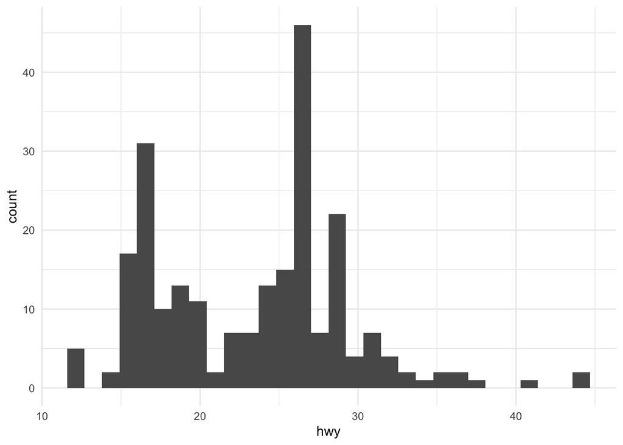

```r
# 2.2.3

ggplot(mpg) +
  geom_histogram(aes(x = hwy))+
  theme_minimal()
```

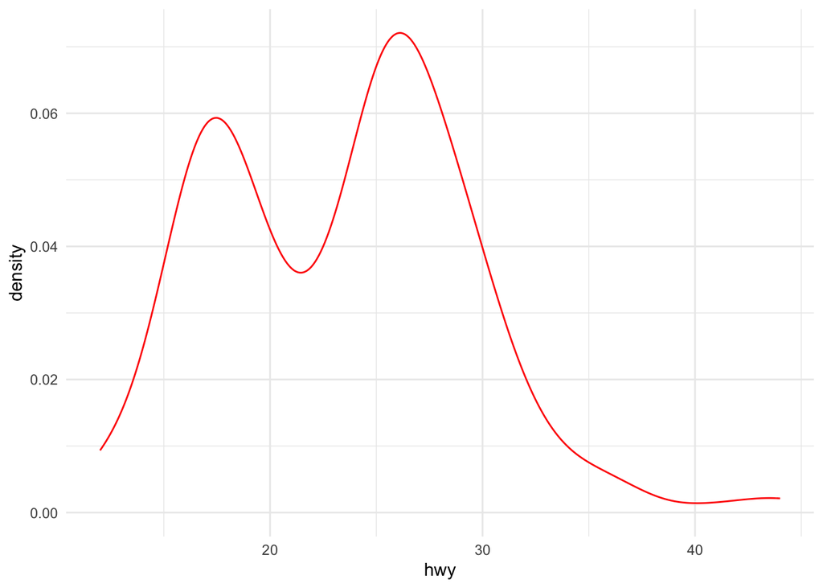

```r
ggplot(mpg) +
  geom_density(aes(x = hwy),color='red')+
  theme_minimal()
```

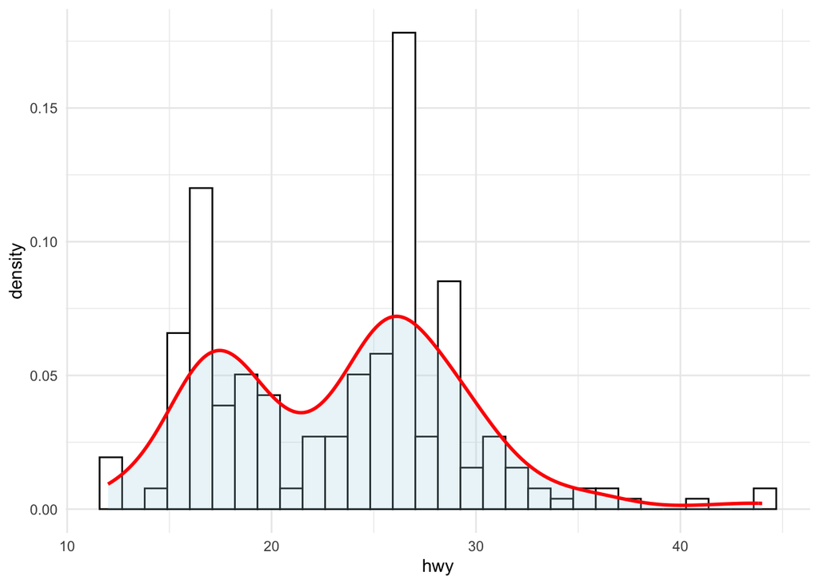

```r
ggplot(mpg,aes(x = hwy)) +
  geom_histogram(aes(y = ..density..),
                 colour = 1, fill = "white") +
  geom_density(lwd = 1, colour = 'red',
               fill = 'lightblue', alpha = 0.25) +
  theme_minimal()
```

Generate a scatter plot and add a regression line with confidence interval

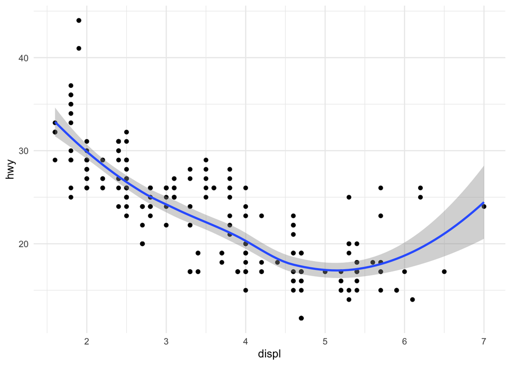

```r
# 2.2.4
ggplot(mpg,aes(x = displ, y = hwy)) +
  geom_point() +
  geom_smooth()+
  theme_minimal()
```

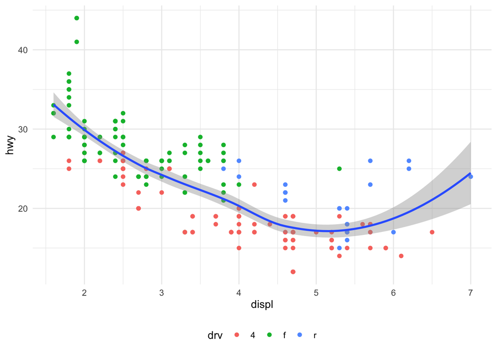

```r
#showing that simple coloring provides already good understanding of patterns in the data
ggplot(mpg,aes(x = displ, y = hwy)) +
  geom_point(aes(color = drv)) +
  geom_smooth()+
  theme_minimal()+
  theme(legend.position = "bottom")
```

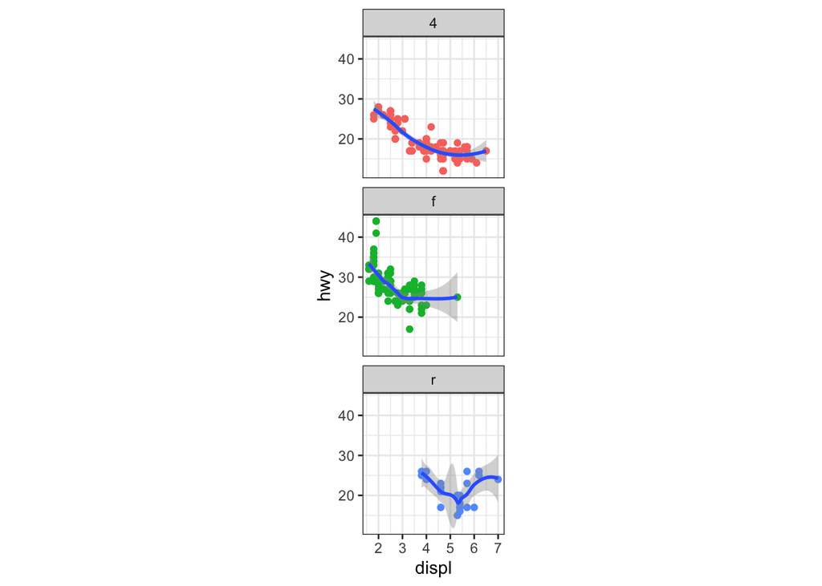

```r
#introducing the facet_wrap function that is very helpful
ggplot(mpg,aes(x = displ, y = hwy)) +
  geom_point(aes(color = drv)) +
  geom_smooth()+
  facet_wrap(~drv,nrow=3)+
  theme_bw()+
  theme(legend.position = "none",aspect.ratio = 1)
```

**Note about colors in R**

Thanks to R we have endless possibilities to generate nice figures and tailor them based on our needs. One of the topics we did not have time to cover extensively is use of colors in R. But you are highly advised to “play” and explore it in your free time…

Specifically, there is a package called RColorBrewer which offers several palettes that can be used to elevate the appearance of your graphics.

Take a look on the following: https://r-graph-gallery.com/38-rcolorbrewers-palettes.html

The following page provides nice examples too:

https://www.sthda.com/english/wiki/colors-in-r?title=colors-in-r

Remember that it is a good practice to use consistent colors when we define different groups in our analysis. For example patients groups and healthy controls can have their own color througout our paper figures. Selecting specific palettes or colors from RColorBrewer and combining it with factor data type allows us to match everywhere group levels to colors.

Simply you can order the factor levels of your categorical data in the order you want, and define a vector of colors where the first color will matches the first factor level, the second color matches the second factor level and so on….

## R exercise on ggplot (e2.2 - optional in class - 30 min)

1. Use the data set `car_price.csv` available in the documentation. Import the data in R.
2. Explore the data.
3. Make a scatterplot of price versus income, use basic plotting instructions and use `ggplot2`.
4. Add a smooth line to each of the plots (using `lines` to add a line to an existing plot and `lowess` to do scatterplot smoothing and using `geom_smooth` in the `ggplot2` grammar).
5. Color the previous ggplot based on sex
6. Transform sex to factor with levels (0,1)
7. Show the plot per different sex in the dataset (use facet_wrap)

# Data wrangling in R (40 min)

We will focus on the `tidyverse`, including the `dplyr` packages which:

- offer advanced, and fast, data handling with large R objects and lots of flexibility
- have a very specific syntax,

In the next lines we will explore their potentials, but first we have to introduce the concept of “pipes”

### Pipes in R

In R, the pipe operator is `%>%`.

You can think of this operator as being similar to the `+` in a ggplot2 statement.

It takes the output of one statement and makes it the input of the next statement.

When describing it, you can think of it as a do this and “THEN” do that…

```r
library(tidyverse)

#2.5
head(diamonds)
```

```
# A tibble: 6 × 10
  carat cut       color clarity depth table price     x     y     z
  <dbl> <ord>     <ord> <ord>   <dbl> <dbl> <int> <dbl> <dbl> <dbl>
1  0.23 Ideal     E     SI2      61.5    55   326  3.95  3.98  2.43
2  0.21 Premium   E     SI1      59.8    61   326  3.89  3.84  2.31
3  0.23 Good      E     VS1      56.9    65   327  4.05  4.07  2.31
4  0.29 Premium   I     VS2      62.4    58   334  4.2   4.23  2.63
5  0.31 Good      J     SI2      63.3    58   335  4.34  4.35  2.75
6  0.24 Very Good J     VVS2     62.8    57   336  3.94  3.96  2.48
```

```r
table(diamonds$cut)
```

```
     Fair      Good Very Good   Premium     Ideal
     1610      4906     12082     13791     21551
```

```r
diamonds$price %>% mean()
```

```
[1] 3932.8
```

```r
#try other similar examples if you wish
#diamonds$price %>% sqrt()
```

An easy way to understand how pipes work is to remember that:

I woke up %>% showered %>% dressed %>% had coffee %>% came to an R course %>% had more coffee

### Data manipulation operators

The `dplyr` package holds many useful data manipulation verbs:

- `mutate()` adds new variables that are functions of existing variables
- `select()` picks variables based on their names
- `filter()` picks cases based on their values
- `summarise()` reduces multiple values down to a single summary
- `arrange()` changes the ordering of the rows.

These all combine naturally with `group_by()` which allows you to perform any operation “by group”.

#### Filter

```r
#2.5.1
filter(diamonds, cut == "Ideal")
```

```
# A tibble: 21,551 × 10
   carat cut   color clarity depth table price     x     y     z
   <dbl> <ord> <ord> <ord>   <dbl> <dbl> <int> <dbl> <dbl> <dbl>
 1  0.23 Ideal E     SI2      61.5    55   326  3.95  3.98  2.43
 2  0.23 Ideal J     VS1      62.8    56   340  3.93  3.9   2.46
 3  0.31 Ideal J     SI2      62.2    54   344  4.35  4.37  2.71
 4  0.3  Ideal I     SI2      62      54   348  4.31  4.34  2.68
 5  0.33 Ideal I     SI2      61.8    55   403  4.49  4.51  2.78
 6  0.33 Ideal I     SI2      61.2    56   403  4.49  4.5   2.75
 7  0.33 Ideal J     SI1      61.1    56   403  4.49  4.55  2.76
 8  0.23 Ideal G     VS1      61.9    54   404  3.93  3.95  2.44
 9  0.32 Ideal I     SI1      60.9    55   404  4.45  4.48  2.72
10  0.3  Ideal I     SI2      61      59   405  4.3   4.33  2.63
# ℹ 21,541 more rows
```

```r
ideal_diamonds <- diamonds %>% filter(cut == "Ideal")
```

#### Mutate

```r
#2.5.2
mutate(diamonds, price_per_carat = price/carat)
```

```
# A tibble: 53,940 × 11
   carat cut   color clarity depth table price     x     y     z price_per_carat
   <dbl> <ord> <ord> <ord>   <dbl> <dbl> <int> <dbl> <dbl> <dbl>           <dbl>
 1  0.23 Ideal E     SI2      61.5    55   326  3.95  3.98  2.43           1417.
 2  0.21 Prem… E     SI1      59.8    61   326  3.89  3.84  2.31           1552.
 3  0.23 Good  E     VS1      56.9    65   327  4.05  4.07  2.31           1422.
 4  0.29 Prem… I     VS2      62.4    58   334  4.2   4.23  2.63           1152.
 5  0.31 Good  J     SI2      63.3    58   335  4.34  4.35  2.75           1081.
 6  0.24 Very… J     VVS2     62.8    57   336  3.94  3.96  2.48           1400
 7  0.24 Very… I     VVS1     62.3    57   336  3.95  3.98  2.47           1400
 8  0.26 Very… H     SI1      61.9    55   337  4.07  4.11  2.53           1296.
 9  0.22 Fair  E     VS2      65.1    61   337  3.87  3.78  2.49           1532.
10  0.23 Very… H     VS1      59.4    61   338  4     4.05  2.39           1470.
# ℹ 53,930 more rows
```

```r
diamonds_updated <- mutate(diamonds, price_per_carat = price/carat)

#combine with filtering
expensive_diamonds <- diamonds %>% mutate(price_per_carat = price/carat) %>%
  filter(price_per_carat > 1500)
```

#### Summarise

```r
#2.5.3
diamonds %>% summarise(mean = mean(price),
                       std_dev = sd(price))
```

```
# A tibble: 1 × 2
   mean std_dev
  <dbl>   <dbl>
1 3933.   3989.
```

#### Group_by

```r
#2.5.4
diamonds %>%
  group_by(cut) %>%
  summarize(price = mean(price), carat = mean(carat))
```

```
# A tibble: 5 × 3
  cut       price carat
  <ord>     <dbl> <dbl>
1 Fair      4359. 1.05
2 Good      3929. 0.849
3 Very Good 3982. 0.806
4 Premium   4584. 0.892
5 Ideal     3458. 0.703
```

**And you can mix-and-match what you have learned so far…**

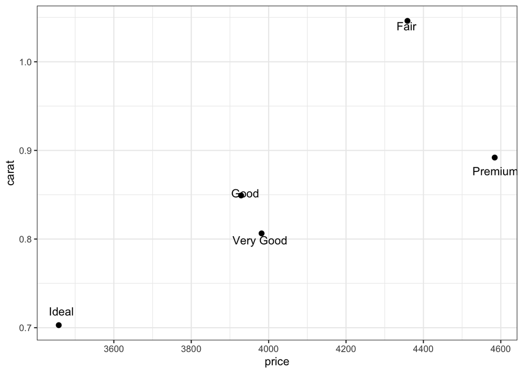

```r
diamonds %>%
  group_by(cut) %>%
  summarize(price = mean(price), carat = mean(carat)) %>%
  ggplot(aes(x=price,y=carat,label=cut))+
  geom_point(size=2)+
  geom_text(position = position_jitter())+
  theme_bw()
```

#### Select

```r
#2.5.5
diamonds_filt <- select(diamonds, carat, cut, clarity,depth)
colnames(diamonds_filt)
```

```
[1] "carat"   "cut"     "clarity" "depth"
```

#### Count

```r
#2.5.6
diamonds %>%
  filter(cut=='Good') %>%
  count(color,sort=TRUE)
```

```
# A tibble: 7 × 2
  color     n
  <ord> <int>
1 E       933
2 F       909
3 G       871
4 H       702
5 D       662
6 I       522
7 J       307
```

```r
# as an alternative syntax without dplyr
good_diamonds <- diamonds[diamonds$cut=='Good',]
table(good_diamonds$color)
```

```
  D   E   F   G   H   I   J
662 933 909 871 702 522 307
```

From the previous example it is obvious that many different and sometimes simpler ways exist to manipulate datasets and perform calculations over the observations they have. Remember that there is not right and wrong solutions, it is often a matter of preference, programming style that you like, speed and readability.

#### Combining different operators to summarise info in the dataset

```r
#2.5.7
diamonds %>%
  mutate(price_per_carat = price/carat) %>%
  group_by(cut,color) %>%
  summarize(mean_carat = mean(carat),
          sd_carat = sd(carat),
          mean_price_per_carat = mean(price_per_carat),
          sd_price_per_carat = sd(price_per_carat),
          mean_depth = mean(depth),
          sd_depth = sd(depth))
```

```
# A tibble: 35 × 8
# Groups:   cut [5]
   cut   color mean_carat sd_carat mean_price_per_carat sd_price_per_carat
   <ord> <ord>      <dbl>    <dbl>                <dbl>              <dbl>
 1 Fair  D          0.920    0.405                4245.              1667.
 2 Fair  E          0.857    0.365                3820.              1564.
 3 Fair  F          0.905    0.419                3788.              1644.
 4 Fair  G          1.02     0.493                3699.              1580.
 5 Fair  H          1.22     0.548                3832.              1458.
 6 Fair  I          1.20     0.522                3515.              1303.
 7 Fair  J          1.34     0.734                3346.              1269.
 8 Good  D          0.745    0.363                3846.              1979.
 9 Good  E          0.745    0.381                3806.              1897.
10 Good  F          0.776    0.370                3821.              1748.
# ℹ 25 more rows
# ℹ 2 more variables: mean_depth <dbl>, sd_depth <dbl>
```

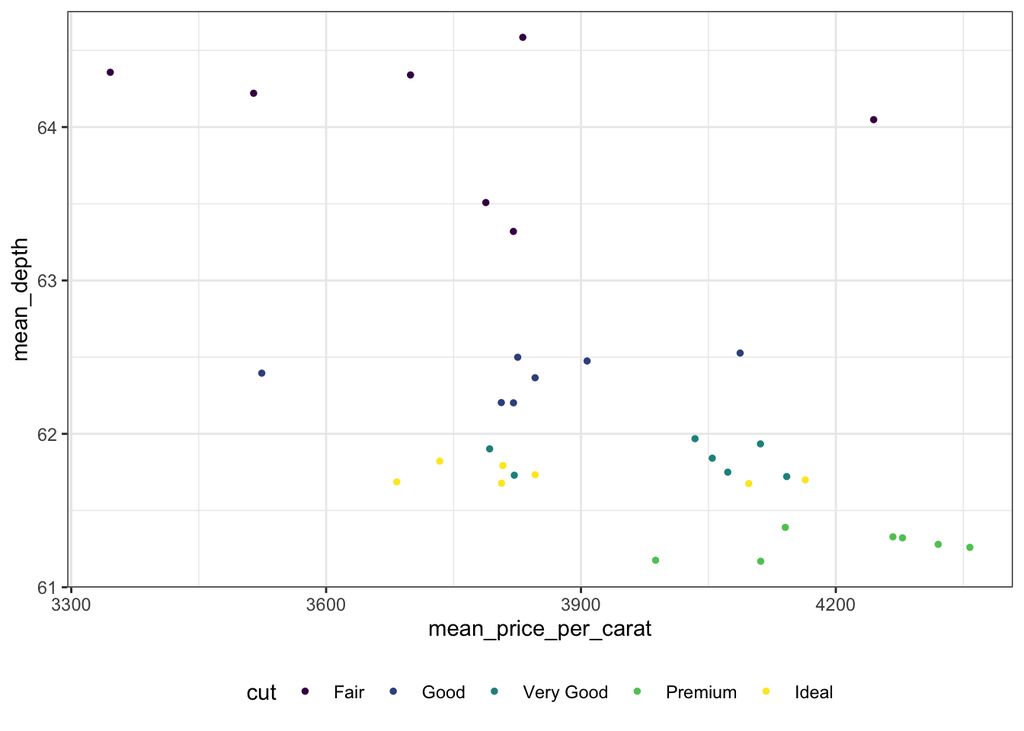

```r
#combine this with a scatter plot
diamonds %>%
  mutate(price_per_carat = price/carat) %>%
  group_by(cut,color) %>%
  summarize(mean_carat = mean(carat),
            se_carat = sd(carat)/length(carat),
            mean_price_per_carat = mean(price_per_carat),
            se_price_per_carat = sd(price_per_carat)/length(price_per_carat),
            mean_depth = mean(depth),
            se_depth = sd(depth)/length(depth)) %>%
  ggplot(aes(x=mean_price_per_carat,y=mean_depth,color=cut)) +
  geom_point(size=1)+
  theme_bw()+
  theme(legend.position = "bottom")
```

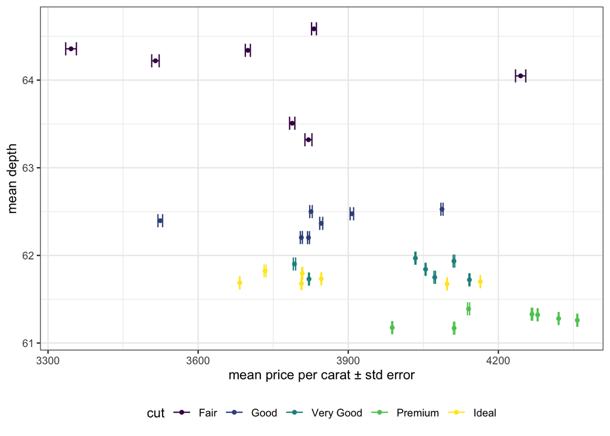

```r
#add the error bars to the scatter plot
diamonds %>%
  mutate(price_per_carat = price/carat) %>%
  group_by(cut,color) %>%
  summarize(mean_carat = mean(carat),
            se_carat = sd(carat)/length(carat),
            mean_price_per_carat = mean(price_per_carat),
            se_price_per_carat = sd(price_per_carat)/length(price_per_carat),
            mean_depth = mean(depth),
            se_depth = sd(depth)/length(depth)) %>%
  ggplot(aes(x=mean_price_per_carat,y=mean_depth,color=cut)) +
  geom_point(size=1.2)+
  ylab('mean depth')+
  xlab('mean price per carat ± std error')+
  geom_errorbar(aes(xmin=mean_price_per_carat-se_price_per_carat,
                    xmax=mean_price_per_carat+se_price_per_carat), width=.15,
                position=position_dodge(0.05))+
  theme_bw()+
  theme(legend.position = "bottom")
```

## R exercise on data wrangling (e2.5 - optional in class - 30 min)

1. Use the data set `gapminder_data.csv` available in the documentation. Import the data in R.
2. Explore the data. Show the top rows of the data set. How many observations does the data set contain?
3. Compute how many records are per continent (either with count or with table functions)
4. Calculate the life expectancy in each continent
5. Convert column country to factor data type
6. Select the data from countries in Asia
7. What are the possible levels for `country` in the subset you created from countries in Asia ?
8. Remove all countries which do not appear in the factor variable (use function droplevels)
9. Now, from all countries countries (gapminder the origianl data frame) select the observations from 2007
10. Bin the life expectancy in four bins of roughly equal size (hint: learn and use functions `quantile` and cut)
11. Visualise how many observations are in each bin (hint use ggplot with geom_bar) and color it based on the continent ((hint: in the aes first color and then fill, what do you see?)